# EV Infrastructure Analysis - Exploratory Data Analysis

import libraries

```r
library(tidyverse)
library(dplyr)
library(janitor)
library(Hmisc)
library(ggplot2)
```

import data from preprocessing

```r
ev_data_by_state <- read_csv("data/ev_data_by_state.csv")
ev_data_by_state
```

| ...1 | state | total_stations | registration_count | population | evs_per_station | people_per_station | pop_with_ev |
| --- | --- | --- | --- | --- | --- | --- | --- |
| 1 | CA | 17797 | 1256646 | 39555674 | 70.61 | 2222.60 | 0.0318 |
| 2 | WA | 2643 | 152101 | 7707586 | 57.55 | 2916.23 | 0.0197 |
| 3 | HI | 383 | 25565 | 1455252 | 66.75 | 3799.61 | 0.0176 |
| 4 | CO | 2495 | 90083 | 5775324 | 36.11 | 2314.76 | 0.0156 |
| 5 | NV | 610 | 47361 | 3105595 | 77.64 | 5091.14 | 0.0153 |
| 6 | OR | 1464 | 64361 | 4237224 | 43.96 | 2894.28 | 0.0152 |
| 7 | NJ | 1586 | 134753 | 9289014 | 84.96 | 5856.88 | 0.0145 |
| 8 | AZ | 1454 | 89798 | 7158110 | 61.76 | 4923.05 | 0.0125 |
| 9 | UT | 923 | 39998 | 3271608 | 43.33 | 3544.54 | 0.0122 |
| 10 | VT | 486 | 7816 | 643082 | 16.08 | 1323.21 | 0.0122 |

[output cut: 40 more lines]

```r
ev_stations_locations <- read_csv("data/ev_station_locations.csv")
ev_stations_locations
```

| ...1 | station_name | city | state | zip | country | latitude | longitude | ev_network |
| --- | --- | --- | --- | --- | --- | --- | --- | --- |
| 1 | Los Angeles Convention Center | Los Angeles | CA | 90015 | US | 34.04054 | -118.27139 | Non-Networked |
| 2 | Scripps Green Hospital | La Jolla | CA | 92037 | US | 32.89947 | -117.24300 | Non-Networked |
| 3 | Galpin Motors | Sepulveda | CA | 91343 | US | 34.22167 | -118.46837 | Non-Networked |
| 4 | Galleria at Tyler | Riverside | CA | 92503 | US | 33.90991 | -117.45905 | Non-Networked |
| 5 | City of Pasadena - Holly Street Garage | Pasadena | CA | 91103 | US | 34.14762 | -118.14711 | Non-Networked |
| 6 | City of Pasadena - De Lacey Garage | Pasadena | CA | 91105 | US | 34.14514 | -118.15265 | Non-Networked |
| 7 | City of Pasadena - Schoolhouse Garage | Pasadena | CA | 91105 | US | 34.14512 | -118.15013 | Non-Networked |
| 8 | Hyatt Regency Long Beach | Long Beach | CA | 90802 | US | 33.76370 | -118.19200 | Non-Networked |
| 9 | Los Angeles International Airport (LAX) - Lot 6 | Los Angeles | CA | 90045 | US | 33.94325 | -118.40334 | Non-Networked |
| 10 | Northridge Fashion Center East Garage Lower Level | Northridge | CA | 91324 | US | 34.23872 | -118.55469 | SHELL_RECHARGE |

[output cut: 990 more lines]

filter to top 10 states with the most EV stations

```r
ev_stations_us_10 <- ev_data_by_state |>
  arrange(desc(total_stations)) |>
  head(10)
ev_stations_us_10
```

| ...1 | state | total_stations | registration_count | population | evs_per_station | people_per_station | pop_with_ev |
| --- | --- | --- | --- | --- | --- | --- | --- |
| 1 | CA | 17797 | 1256646 | 39555674 | 70.61 | 2222.60 | 0.0318 |
| 23 | NY | 4920 | 131250 | 20203772 | 26.68 | 4106.46 | 0.0065 |
| 18 | TX | 3834 | 230125 | 29149458 | 60.02 | 7602.88 | 0.0079 |
| 13 | MA | 3810 | 73768 | 7033132 | 19.36 | 1845.97 | 0.0105 |
| 11 | FL | 3801 | 254878 | 21538192 | 67.06 | 5666.45 | 0.0118 |
| 2 | WA | 2643 | 152101 | 7707586 | 57.55 | 2916.23 | 0.0197 |
| 4 | CO | 2495 | 90083 | 5775324 | 36.11 | 2314.76 | 0.0156 |
| 16 | GA | 2173 | 92368 | 10713755 | 42.51 | 4930.40 | 0.0086 |
| 26 | PA | 1967 | 70154 | 13002909 | 35.67 | 6610.53 | 0.0054 |
| 21 | NC | 1863 | 70164 | 10441499 | 37.66 | 5604.67 | 0.0067 |

visualize top 10 states with the most EV stations

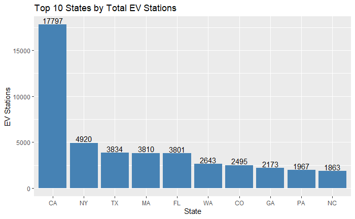

```r
ggplot(ev_stations_us_10, aes(x = reorder(state, -total_stations), y = total_stations)) +
  geom_bar(stat = "identity", fill = "steelblue") +
  labs(
    title = "Top 10 States by Total EV Stations",
    x = "State",
    y = "EV Stations"
  ) +
  geom_text(aes(label = total_stations), vjust = -0.2)
ggsave("outputs/charts/top_10_states_total_ev_stations.png")
```

visualize all US charging station locations (continental US only)

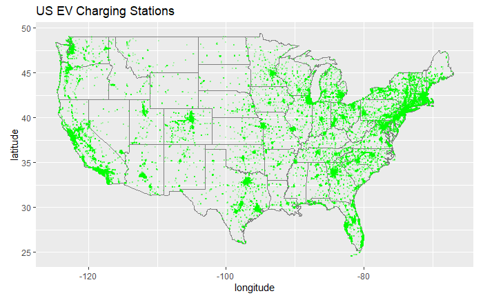

```r
library(maps)

ggplot(ev_stations_locations, aes(x = longitude, y = latitude)) +
  borders("state") +
  geom_point(alpha = 0.2, color = "green", size = 0.3) +
  coord_fixed(1.3) +
  labs(title = "US EV Charging Stations")

ggsave("outputs/usa_maps/us_ev_charging_station_map.png")
```

visualize with heat map show states with largest proportion of EVs to the available charging stations these states may be underdeveloped and in need of additional EV station rollout yellow and orange states may need more stations based on the number of vehicles currently registered

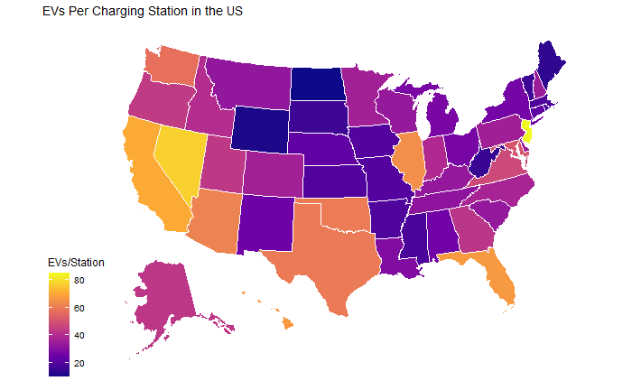

```r
library(usmap)

plot_usmap(data = ev_data_by_state, values = "evs_per_station", color = "white") +
  scale_fill_viridis_c(option = "C") +
  labs(title = "EVs Per Charging Station in the US",
       fill = "EVs/Station")

ggsave("outputs/usa_maps/evs_per_charging_station_us.png", bg = "grey")
```

visualize with heat map show states with the largest proportion of people to the available charging stations these states have the highest populations relative to the number of stations yellow and orange states may be in need of more EV stations based on state population

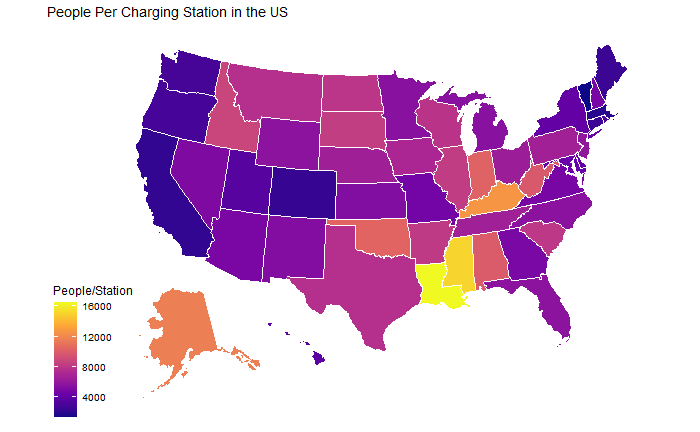

```r
plot_usmap(data = ev_data_by_state, values = "people_per_station", color = "white") +
  scale_fill_viridis_c(option = "C") +
  labs(title = "People Per Charging Station in the US",
       fill = "People/Station")

ggsave("outputs/usa_maps/people_per_charging_station_us.png", bg = "grey")
```

visualize with heat map show states with the largest highest EV saturation (EV registrations / population) yellow and orange states could be considered the faster-growing markets compared to purple and blue states as expected, California has the highest saturation of EVs followed by other Pacific Coast states other states may see jumps in saturation in the coming decades and would require additional EV stations

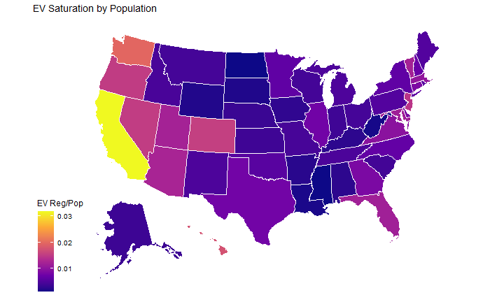

```r
plot_usmap(data = ev_data_by_state, values = "pop_with_ev", color = "white") +
  scale_fill_viridis_c(option = "C") +
  labs(title = "EV Saturation by Population",
       fill = "EV Reg/Pop")

ggsave("outputs/usa_maps/ev_saturation_by_population.png", bg = "grey")
```